# PS5: RMarkdown Manipulations

Rosemary Randall

2023-02-20

## Loading and checking the data

1.2: Load the data and determine its dimensions:

```r
library("tidyverse")
gaps <- read_delim("gapminder.csv.bz2")
row <- nrow(gaps)
col <- ncol(gaps)
```

There are 13055 rows in this dataset, attributed by 25 columns. (1.3) Here’s a sample:

```r
gaps %>%
  sample_n(10)
```

```
## # A tibble: 10 × 25
##    iso3  name         iso2  region sub-r…¹ inter…²  time total…³ ferti…⁴ lifeE…⁵
##    <chr> <chr>        <chr> <chr>  <chr>   <chr>   <dbl>   <dbl>   <dbl>   <dbl>
##  1 MMR   Myanmar      MM    Asia   South-… <NA>     1983  3.65e7    4.50    54.1
##  2 UZB   Uzbekistan   UZ    Asia   Centra… <NA>     1976  1.42e7    5.70    63.7
##  3 MNP   Northern Ma… MP    Ocean… Micron… <NA>     1972  1.39e4   NA       NA
##  4 BEN   Benin        BJ    Africa Sub-Sa… Wester…  1976  3.35e6    6.96    45.4
##  5 TJK   Tajikistan   TJ    Asia   Centra… <NA>     1966  2.57e6    7.00    52.5
##  6 MNP   Northern Ma… MP    Ocean… Micron… <NA>     1963  1.06e4   NA       NA
##  7 MAF   Saint Marti… MF    Ameri… Latin … Caribb…  2019  3.80e4    1.81    80.0
##  8 TZA   Tanzania, U… TZ    Africa Sub-Sa… Easter…  1996  3.04e7    5.83    49.3
##  9 BFA   Burkina Faso BF    Africa Sub-Sa… Wester…  2005  1.34e7    6.26    53.3
## 10 LBY   Libya        LY    Africa Northe… <NA>     2005  5.80e6    2.53    71.9
## # … with 15 more variables: childMortality <dbl>, youthFemaleLiteracy <dbl>,
## #   youthMaleLiteracy <dbl>, adultLiteracy <dbl>, GDP_PC <dbl>,
## #   accessElectricity <dbl>, agriculturalLand <dbl>, agricultureTractors <dbl>,
## #   cerealProduction <dbl>, fertilizerHa <dbl>, co2 <dbl>,
## #   greenhouseGases <dbl>, co2_PC <dbl>, pm2.5_35 <dbl>, battleDeaths <dbl>,
## #   and abbreviated variable names ¹`sub-region`, ²`intermediate-region`,
## #   ³totalPopulation, ⁴fertilityRate, ⁵lifeExpectancy
```

## Descriptive Statistics

2.1: How many countries are there, by each identifying metric?

```r
countName <- length(unique(gaps$name))

countIso3 <- length(unique(gaps$iso3))

countIso2 <- length(unique(gaps$iso2))
```

There are 253 3-letter country name abbreviations, 250 unique country names, and 249 2-letter country name abbreviations.

2.2a: What’s going on here? If there are fewer than 250 ISO2 abbreviations, that means that some are used multiple times.

```r
gaps %>%
  group_by(iso2) %>%
  summarize(num = n_distinct(name)) %>%
  arrange(desc(num)) %>%
  head(3)
```

```
## # A tibble: 3 × 2
##   iso2    num
##   <chr> <int>
## 1 <NA>      2
## 2 AD        1
## 3 AE        1
```

This shows that “NA” is being used twice for an ISO2 abbreviation, resulting in the lower number.

2.2b: What about for the ISO3 abbreviations? Do any countries use multiple codes?

```r
gaps %>%
  group_by(name) %>%
  summarize(abbNum = n_distinct(iso3)) %>%
  arrange(desc(abbNum)) %>%
  head(3)
```

```
## # A tibble: 3 × 2
##   name        abbNum
##   <chr>        <int>
## 1 <NA>             4
## 2 Afghanistan      1
## 3 Albania          1
```

This shows that countries with the name “NA” are given 4 different ISO3 abbreviations, resulting in the higher number.

2.3: What are the most and least recent years in the data?

```r
max(gaps$time, na.rm = TRUE)
```

```
## [1] 2019
```

```r
min(gaps$time, na.rm = TRUE)
```

```
## [1] 1960
```

The earliest data was collected was 1960, while the latest was 2019.

## CO2 Emissions

3.1: How many missing CO2 emissions are there per year? Which years have the most missing?

```r
gaps %>%
  group_by(gaps$time) %>%
  filter(is.na(co2) | is.na(co2_PC)) %>%
  count() %>%
  arrange(desc(n)) %>%
  head(5)
```

```
## # A tibble: 5 × 2
## # Groups:   gaps$time [5]
##   `gaps$time`     n
##         <dbl> <int>
## 1        2017   217
## 2        2018   217
## 3        2019   217
## 4        1960    60
## 5        1961    60
```

Evidently, more recent years have the most missing data for carbon emissions. This might be due to bureaucratic delays or ongoing political machinations - either way, it takes time to report this information!

3.2: What are the total CO2 emissions over time for the U.S., China, and India, plus additional countries?

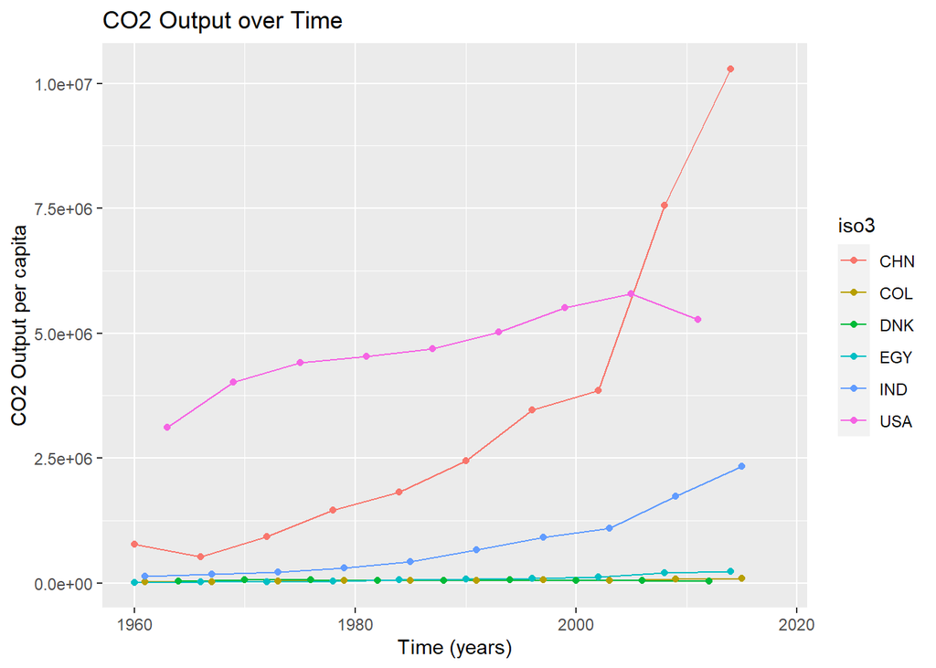

```r
gaps %>%
  filter(iso3 == c("USA", "IND", "CHN", "DNK", "COL", "EGY")) %>%
  ggplot() +
  geom_line(aes(x = time, y = co2, col = iso3)) +
  geom_point(aes(x = time, y = co2, col = iso3)) +
  labs(x = "Time (years)", y = "CO2 Output per capita", title = "CO2 Output over Time")
```

Somewhat unsurprisingly, China and India’s CO2 emissions begin increasing around 2000 when a boom in technology production began as well as a population spike in both countries, resulting in increased emissions, while the US has remained on a semi-steady increase until that point as well, when it began to decrease. Most of the other countries remained relatively small, either due to size or increase in sustainable energy.

3.3: Does this change when viewing CO2 emmittance on a *per capita* basis?

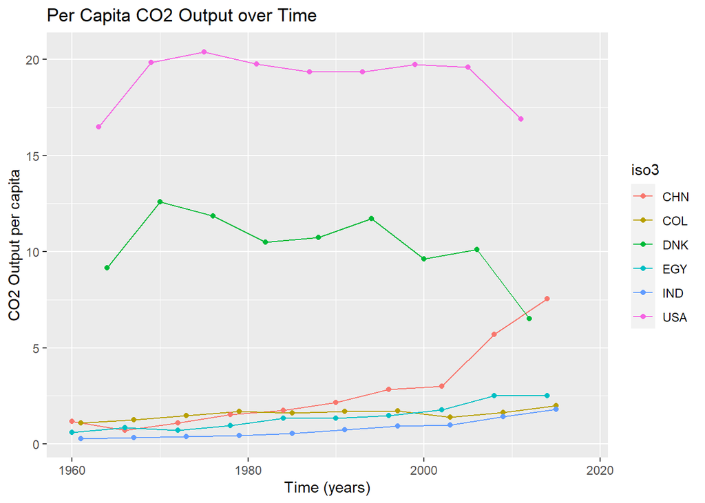

```r
gaps %>%
  filter(iso3 == c("USA", "IND", "CHN", "DNK", "COL", "EGY")) %>%
  ggplot() +
  geom_line(aes(x = time, y = co2_PC, col = iso3)) +
  geom_point(aes(x = time, y = co2_PC, col = iso3)) +
  labs(x = "Time (years)", y = "CO2 Output per capita", title = "Per Capita CO2 Output over Time")
```

The trends from the previous graph often hold the same, with most increasing around 2000. However, curious is Denmark’s trend, which starts higher than one might expect from a small nation - but given that this data is *per capita* that might indicate some of that variance.

3.4: What is the average CO2 emission *per capita* for each of the regions?

```r
gaps %>%
  filter(!is.na(region), !is.na(name)) %>%
  group_by(region, time) %>%
  summarize(meanEmit = mean(co2_PC, na.rm = TRUE)) %>%
  filter(time == 1960 | time == 2016) %>%
  arrange(desc(time)) %>%
  arrange(desc(meanEmit))
```

```
## # A tibble: 10 × 3
## # Groups:   region [5]
##    region    time meanEmit
##    <chr>    <dbl>    <dbl>
##  1 Americas  1960    7.15
##  2 Europe    2016    6.64
##  3 Asia      2016    6.47
##  4 Europe    1960    5.77
##  5 Americas  2016    4.80
##  6 Oceania   2016    4.57
##  7 Oceania   1960    2.73
##  8 Asia      1960    1.74
##  9 Africa    2016    1.20
## 10 Africa    1960    0.291
```

This shows that the Americas in the 1960s had the highest *per capita* CO2 emissions, while in 2016 Europe has the highest.

3.5: Here is a graph illustrating these results:

```r
avgs <- gaps %>%
  group_by(region, time) %>%
  filter(!is.na(region), !is.na(name)) %>%
  summarize(meanEmit = mean(co2_PC, na.rm = TRUE)) %>%
  filter(time == 1960 | time == 2016) %>%
  arrange(desc(meanEmit))
```

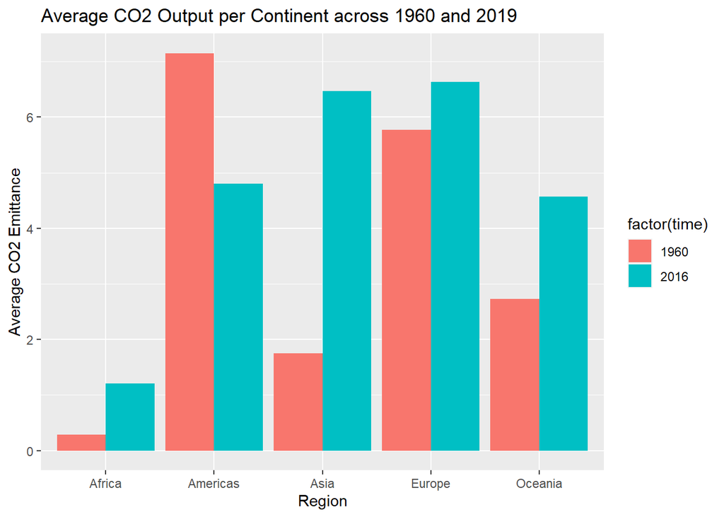

```r
  ggplot(data = avgs) +
  geom_bar(aes(x = region, y = meanEmit, fill = factor(time)), stat = "identity", position = "dodge") +
  labs(x = "Region", y = "Average CO2 Emittance", title = "Average CO2 Output per Continent across 1960 and 2019")
```

3.6: The three largest and smallest emitters per region are as follows:

```r
gaps %>%
  filter(time == 2016, !is.na(co2_PC)) %>%
  group_by(region) %>%
  arrange(co2_PC) %>%
  slice_head(n = 3) %>%
  select(region, name, co2_PC)
```

```
## # A tibble: 17 × 3
## # Groups:   region [6]
##    region   name                               co2_PC
##    <chr>    <chr>                               <dbl>
##  1 Africa   Congo, Democratic Republic of the  0.0256
##  2 Africa   Somalia                            0.0455
##  3 Africa   Burundi                            0.0472
##  4 Americas Haiti                              0.275
##  5 Americas Nicaragua                          0.887
##  6 Americas Honduras                           1.06
##  7 Asia     Afghanistan                        0.245
##  8 Asia     Nepal                              0.334
##  9 Asia     Yemen                              0.390
## 10 Europe   Liechtenstein                      1.36
## 11 Europe   Albania                            1.58
## 12 Europe   Moldova, Republic of               1.83
## 13 Oceania  Solomon Islands                    0.272
## 14 Oceania  Vanuatu                            0.527
## 15 Oceania  Kiribati                           0.587
## 16 <NA>     <NA>                               5.03
## 17 <NA>     <NA>                              33.8
```

```r
gaps %>%
  filter(time == 2016, !is.na(co2_PC)) %>%
  group_by(region) %>%
  arrange(co2_PC) %>%
  slice_tail(n = 3) %>%
  select(region, name, co2_PC)
```

```
## # A tibble: 17 × 3
## # Groups:   region [6]
##    region   name                     co2_PC
##    <chr>    <chr>                     <dbl>
##  1 Africa   Seychelles                 6.39
##  2 Africa   Libya                      7.79
##  3 Africa   South Africa               8.48
##  4 Americas Canada                    15.1
##  5 Americas United States of America  15.5
##  6 Americas Trinidad and Tobago       31.8
##  7 Asia     Bahrain                   22.2
##  8 Asia     Kuwait                    25.0
##  9 Asia     Qatar                     38.9
## 10 Europe   Faroe Islands             13.1
## 11 Europe   Luxembourg                15.4
## 12 Europe   Gibraltar                 18.8
## 13 Oceania  Palau                     12.6
## 14 Oceania  Australia                 15.5
## 15 Oceania  New Caledonia             19.3
## 16 <NA>     <NA>                       5.03
## 17 <NA>     <NA>                      33.8
```

## GDP Per Capita

4.1: Make a scatterplot of GDP per capita versus life expectancy by country, using data for 1960. Make the point size dependent on the country size, and color those according to the continent. Feel free to adjust the plot in other ways to make it better.

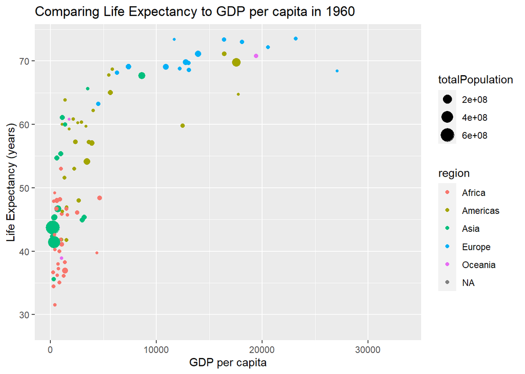

```r
LE1960 <- gaps %>%
  filter(time == 1960)
ggplot(data = LE1960) +
  geom_point(aes(x = GDP_PC, y = lifeExpectancy, color = region,
                 size = totalPopulation)) +
  labs(x = "GDP per capita", y = "Life Expectancy (years)", title = "Comparing Life Expectancy to GDP per capita in 1960")
```

This shows a positive corelation between *per capita* GDP (a measure of national wealth) and *per capita* life expectancy - which makes sense, given that wealthier countries are more likely to have more robust healthcare and education systems.

4.2: Make the same graph, but with 2019 data.

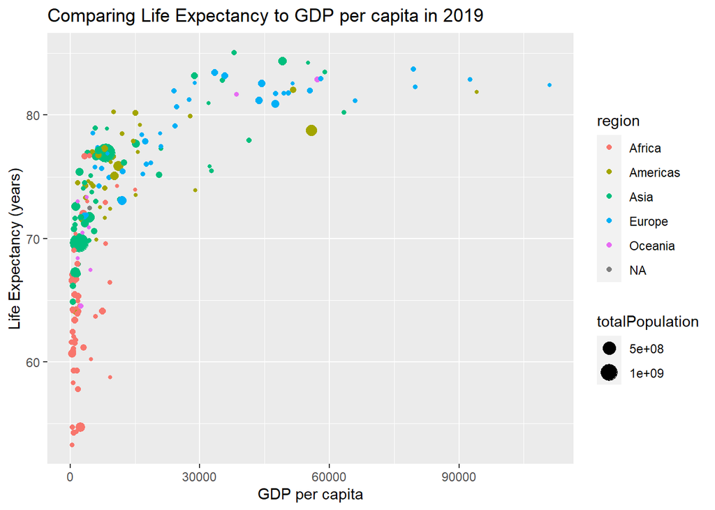

```r
LE2019 <- gaps %>%
  filter(time == 2019)
ggplot(data = LE2019) +
  geom_point(aes(x = GDP_PC, y = lifeExpectancy, color = region,
                 size = totalPopulation)) +
  labs(x = "GDP per capita", y = "Life Expectancy (years)", title = "Comparing Life Expectancy to GDP per capita in 2019")
```

4.3: The differences between these two charts shows a general increase for the regions towards higher GDP and higher life expectancy, which is to be expected with the prior sixty years of increased globalization and industrialization, both of which tend to increase wealth and drives education and technology to be better via international scientific collaboration.

4.4: What is the average life expectancy overall for each continent between 1960 and 2019? Does that align with the figures?

```r
gaps %>%
  filter(time == 2019, !is.na(lifeExpectancy), !is.na(region)) %>%
  group_by(region) %>%
  summarize(meanLE = mean(lifeExpectancy))
```

```
## # A tibble: 5 × 2
##   region   meanLE
##   <chr>     <dbl>
## 1 Africa     64.1
## 2 Americas   75.8
## 3 Asia       74.6
## 4 Europe     79.4
## 5 Oceania    73.5
```

```r
gaps %>%
  filter(time == 1960, !is.na(lifeExpectancy), !is.na(region)) %>%
  group_by(region) %>%
  summarize(meanLE = mean(lifeExpectancy))
```

```
## # A tibble: 5 × 2
##   region   meanLE
##   <chr>     <dbl>
## 1 Africa     41.5
## 2 Americas   58.6
## 3 Asia       51.6
## 4 Europe     68.3
## 5 Oceania    56.4
```

This matches the overall increase in both life expectancy and per capita GDP in all regions in accordance with progress into a more modern era on all fronts.

4.5: Find Average LE growth from 1960 to 2019 across the continents in order of growth.

```r
gaps %>%
  group_by(region) %>%
  group_by(time) %>%
  filter(!is.na(lifeExpectancy), !is.na(region)) %>%
  mutate(prev = lag(lifeExpectancy),
         growth = lifeExpectancy - prev) %>%
  mutate(meanGrowth = mean(growth), na.rm = TRUE) %>%
  select(iso3, name, region, time, lifeExpectancy, prev, growth, meanGrowth) %>%
  arrange(desc(growth))
```

```
## # A tibble: 11,618 × 8
## # Groups:   time [60]
##    iso3  name         region  time lifeExpectancy  prev growth meanGrowth
##    <chr> <chr>        <chr>  <dbl>          <dbl> <dbl>  <dbl>      <dbl>
##  1 SAU   Saudi Arabia Asia    1993           70.3  26.2   44.2         NA
##  2 SAU   Saudi Arabia Asia    1992           69.9  26.7   43.3         NA
##  3 SAU   Saudi Arabia Asia    1994           70.7  27.7   43.0         NA
##  4 MLT   Malta        Europe  1961           69.6  28.3   41.3         NA
##  5 MLT   Malta        Europe  1962           69.8  28.5   41.2         NA
##  6 MLT   Malta        Europe  1960           69.4  28.2   41.2         NA
##  7 MLT   Malta        Europe  1963           69.9  28.8   41.1         NA
##  8 MLT   Malta        Europe  1964           70.1  29.1   41.0         NA
##  9 MLT   Malta        Europe  1965           70.2  29.5   40.8         NA
## 10 MLT   Malta        Europe  1966           70.4  30.0   40.5         NA
## # … with 11,608 more rows
```

```r
gaps %>%
  group_by(region, time) %>%
  filter(!is.na(lifeExpectancy), !is.na(region), time == 1960 | time == 2019) %>%
  summarise(avgLEgrowth = mean(lifeExpectancy)) %>%
  mutate(prev = lag(avgLEgrowth), growth = avgLEgrowth - prev) %>%
  filter(!is.na(growth)) %>%
  arrange(desc(growth))
```

```
## # A tibble: 5 × 5
## # Groups:   region [5]
##   region    time avgLEgrowth  prev growth
##   <chr>    <dbl>       <dbl> <dbl>  <dbl>
## 1 Asia      2019        74.6  51.6   23.0
## 2 Africa    2019        64.1  41.5   22.6
## 3 Americas  2019        75.8  58.6   17.2
## 4 Oceania   2019        73.5  56.4   17.1
## 5 Europe    2019        79.4  68.3   11.1
```

These results indicate that Asia experienced the highest average growth in life expectancy, likely due to both rapidly increasing population and great increases in globalization, technology, and rises in social capital in places like South Korea and China, as well as recovery from drastic population life expectancy decreasing events (such as the rise and fall of the Pol Pot Regime in Cambodia which skews the data downward.)

4.6: Make a histogram of GDP *per capita* for the years 1960 and 2019 on the same graph.

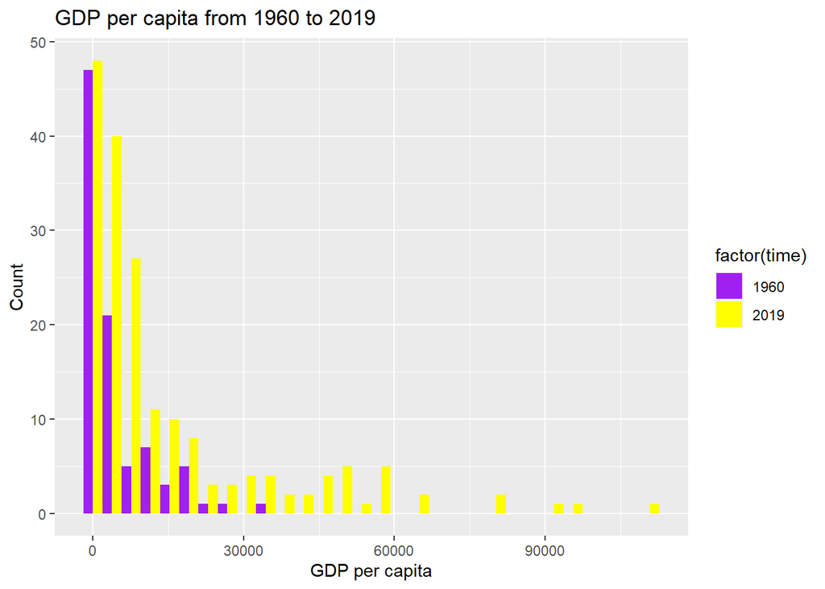

```r
gdps <- gaps %>%
  group_by(time) %>%
  filter(!is.na(GDP_PC), !is.na(name)) %>%
  filter(time == 1960 | time == 2019)

  ggplot(data = gdps) +
    geom_histogram(aes(x = GDP_PC, fill = factor(time)),
                   position = "dodge", bins = 30) +
     scale_fill_manual(values = c("purple", "yellow"), labels = c("1960", "2019")) +
    labs(x = "GDP per capita", y = "Count", title = "GDP per capita from 1960 to 2019")
```

This figure shows a much greater number of lower-GDP nations in both years, but a relatively large increase in GDP across the total nations (ignoring size) as time progresses, with many nations achieving a much higher GDP than the highest possible in 1960. Overall this indicates a growth in international wealth.

4.7: What was the ranking of the US in terms of life expectancy in 1960 compared to 2019 (when counting from the top?)

```r
gaps %>%
  filter(time == 1960, !is.na(name)) %>%
  mutate(rank = rank(desc(lifeExpectancy))) %>%
  summarize(iso3, name, lifeExpectancy, rank) %>%
  filter(iso3 == "USA")
```

```
## # A tibble: 1 × 4
##   iso3  name                     lifeExpectancy  rank
##   <chr> <chr>                             <dbl> <dbl>
## 1 USA   United States of America           69.8    17
```

```r
gaps %>%
  filter(time == 2019, !is.na(name)) %>%
  mutate(rank = rank(desc(lifeExpectancy))) %>%
  summarize(iso3, name, lifeExpectancy, rank) %>%
  filter(iso3 == "USA")
```

```
## # A tibble: 1 × 4
##   iso3  name                     lifeExpectancy  rank
##   <chr> <chr>                             <dbl> <dbl>
## 1 USA   United States of America           78.8    46
```

We notice that the US’s ranking in terms of life expectancy has dropped significantly in the years between 1960 and 2019. However, given that we also see an almost 10-year jump in life expectancy for the US, it’s more reasonable to assume that other countries are attaining higher life expectancies than the US’s is getting worse.

4.8: Given the US’s falling ranking, but also the increased number of countries in 2019 as compared to 1960, what is the relative rank divided by the corresponding number of countries in the given year? (rank/number of countries)

```r
gaps %>%
  filter(time == 1960, !is.na(name)) %>%
  mutate(rank = rank(desc(lifeExpectancy))) %>%
  mutate(relRank = rank/n_distinct(name)) %>%
  summarize(iso3, name, lifeExpectancy, rank, relRank) %>%
  filter(iso3 == "USA")
```

```
## # A tibble: 1 × 5
##   iso3  name                     lifeExpectancy  rank relRank
##   <chr> <chr>                             <dbl> <dbl>   <dbl>
## 1 USA   United States of America           69.8    17  0.0802
```

```r
gaps %>%
  filter(time == 2019, !is.na(name)) %>%
  mutate(rank = rank(desc(lifeExpectancy))) %>%
  mutate(relRank = rank/n_distinct(name)) %>%
  summarize(iso3, name, lifeExpectancy, rank, relRank) %>%
  filter(iso3 == "USA")
```

```
## # A tibble: 1 × 5
##   iso3  name                     lifeExpectancy  rank relRank
##   <chr> <chr>                             <dbl> <dbl>   <dbl>
## 1 USA   United States of America           78.8    46   0.216
```

Bonus: I spent somewhere in the ballpark of 10 hours on this problemset across 3 days.